# week 2 test

ashy

10 November 2017

=============================================

## Week 2 test

Loading the data set We have many NA’s in out “steps” column

```r
Week2 <- read.csv("C:\\Ashy\\Ashy\\cousera\\Reproducible research\\week 2\\activity.csv")

summary(Week2)
```

```
##      steps                date          interval
##  Min.   :  0.00   2012-10-01:  288   Min.   :   0.0
##  1st Qu.:  0.00   2012-10-02:  288   1st Qu.: 588.8
##  Median :  0.00   2012-10-03:  288   Median :1177.5
##  Mean   : 37.38   2012-10-04:  288   Mean   :1177.5
##  3rd Qu.: 12.00   2012-10-05:  288   3rd Qu.:1766.2
##  Max.   :806.00   2012-10-06:  288   Max.   :2355.0
##  NA's   :2304     (Other)   :15840
```

```r
table(is.na(Week2$steps))
```

```
##
## FALSE  TRUE
## 15264  2304
```

```r
str(Week2)
```

```
## 'data.frame':    17568 obs. of  3 variables:
##  $ steps   : int  NA NA NA NA NA NA NA NA NA NA ...
##  $ date    : Factor w/ 61 levels "2012-10-01","2012-10-02",..: 1 1 1 1 1 1 1 1 1 1 ...
##  $ interval: int  0 5 10 15 20 25 30 35 40 45 ...
```

What is mean total number of steps taken per day?

For this part of the assignment, you can ignore the missing values in the dataset.

Calculate the total number of steps taken per day #Week2$steps[is.na(Week2$steps)] <- 0 #replacing the NA’s with Zero

```r
steps <- aggregate(Week2$steps, by = list(Date = Week2$date), FUN = sum)

names(steps)[names(steps) == "x"] <- "Total"
temp <- as.Date(steps$Date, "%Y-%m-%d")
steps$Date <- format(temp, format = "%m-%d")
head(steps)
```

```
##    Date Total
## 1 10-01    NA
## 2 10-02   126
## 3 10-03 11352
## 4 10-04 12116
## 5 10-05 13294
## 6 10-06 15420
```

Make a histogram of the total number of steps taken each day.

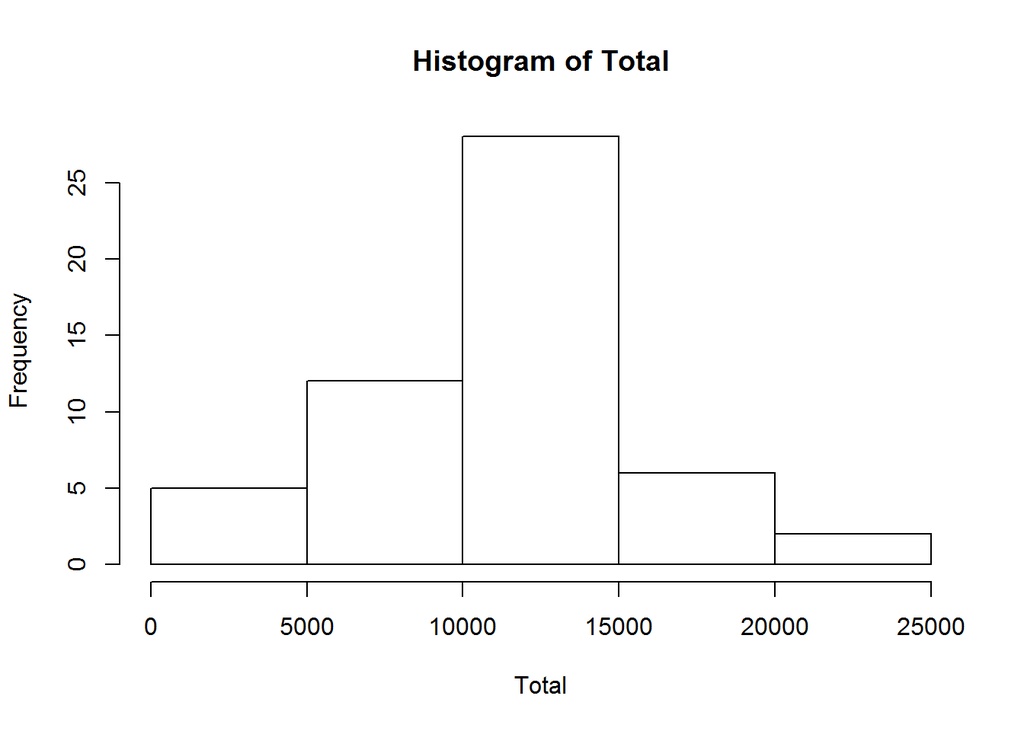

```r
with(steps,hist(Total))
```

Calculate and report the mean and median of the total number of steps taken per day

```r
mean(steps$Total,na.rm = TRUE)
```

```
## [1] 10766.19
```

```r
median(steps$Total,na.rm = TRUE)
```

```
## [1] 10765
```

What is the average daily activity pattern? Make a time series plot (i.e. type = “l”) of the 5-minute interval (x-axis) and the average number of steps taken, averaged across all days (y-axis)

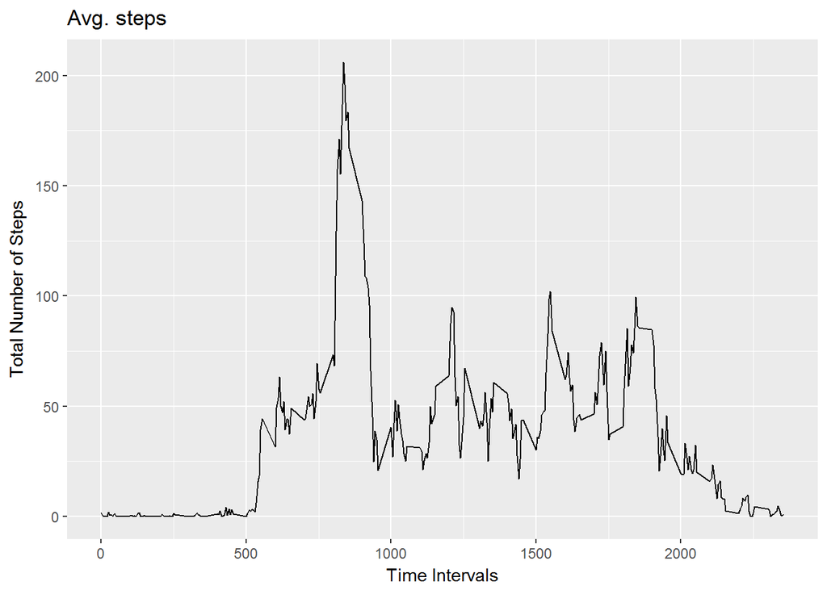

```r
library(ggplot2)

Five_Min <- aggregate(steps ~ interval, data = Week2, FUN =mean)

TimeSeries <- ggplot(data = Five_Min, aes(x = interval, y = steps)) +
    geom_line() +
    xlab("Time Intervals") +
    ylab("Total Number of Steps") +
    ggtitle("Avg. steps")

print(TimeSeries)
```

Which 5-minute interval, on average across all the days in the dataset, contains the maximum number of steps?

```r
Five_Min[which(Five_Min$steps == max(Five_Min$steps)),]
```

```
##     interval    steps
## 104      835 206.1698
```

Imputing missing values Calculate and report the total number of missing values in the dataset (i.e. the total number of rows with NAs)

```r
sapply(X = Week2, FUN = function(x) sum(is.na(x)))
```

```
##    steps     date interval
##     2304        0        0
```

Devise a strategy for filling in all of the missing values in the dataset. The strategy does not need to be sophisticated. For example, you could use the mean/median for that day, or the mean for that 5-minute interval, etc

Create a new dataset that is equal to the original dataset but with the missing data filled in

```r
table(is.na(Week2$steps))
```

```
##
## FALSE  TRUE
## 15264  2304
```

```r
table(is.na(Week2$date))
```

```
##
## FALSE
## 17568
```

```r
table(is.na(Week2$interval))
```

```
##
## FALSE
## 17568
```

```r
Week2$steps[is.na(Week2$steps)] <- mean(Week2$steps,na.rm = TRUE)
table(is.na(Week2$steps))
```

```
##
## FALSE
## 17568
```

```r
table(is.na(Week2))
```

```
##
## FALSE
## 52704
```